# Saints Fan Persona Analysis

Neighborhood Intelligence & Sponsorship Alignment

Author

Nathan Vernon

# **Executive Summary**

This analysis identifies the demographic and economic drivers of Saints fan loyalty. By merging primary survey data with U.S. Census Bureau American Community Survey (ACS) metrics, we can get a more holistic view of the Saints Fandom. This report specifically examines how neighborhood-level wealth and education correlate with fan passion. The findings of the report apply to the persona of Saints fans and their relation to their neighborhoods.

## Exploratory Data Analysis

Exploratory data analysis began with the production of univariate plots to provide an initial understanding of the fanbase.

### Response Variable: Fan Passion

The primary response variable of interest is overall Fan Passion. Because passion is multifaceted, this metric was calculated as an aggregated index (0-100) using four distinct survey questions regarding fan loyalty and engagement.

As illustrated in Figure 1, the distribution of passion values follows a left-skewed pattern. Most observations fall around 95, indicating that the Saints fan base in this sample are very passionate.

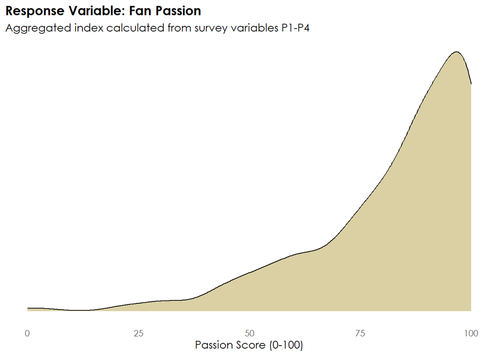

Figure 1: Distribution of Calculated Fan Passion Scores

### Predictor: Neighborhood Economics

To understand the geographic context of the fanbase, I analyzed the relationship between a fan’s stated passion and the median household income of their ZIP Code Tabulation Area (ZCTA) using U.S. Census Bureau ACS data.

When compared with overall passion, the neighborhood income variable demonstrates a statistically flat relationship with a slight negative trend (Figure 2). This suggests that Saints fan passion move beyond economic boundaries, and that the most deeply engaged fans are slightly more concentrated in middle-to-lower-income neighborhoods.

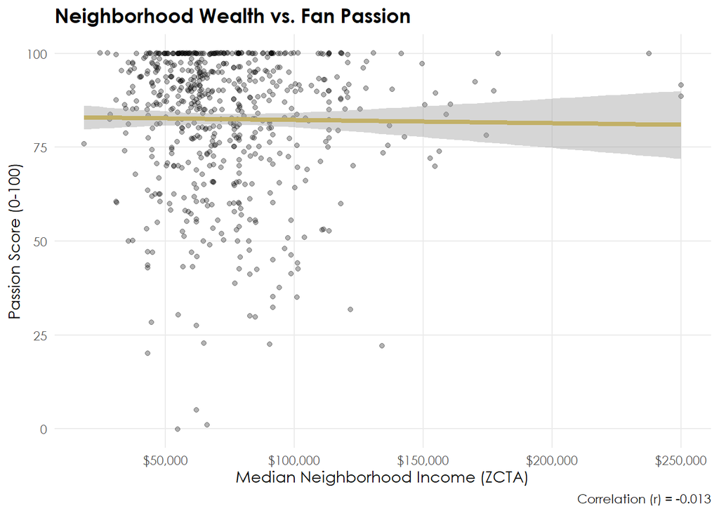

Figure 2: Relationship between Neighborhood Income and Fan Passion

### Predictor (Categorical): Season Ticket Holder Status

When segmenting the Saints fan base by Season Ticket Holder (STH) status, the data reveals that average passion scores are nearly identical across both groups (Figure 3).

This indicates a highly ubiquitous and deeply entrenched fan base. Unlike markets where passion is heavily concentrated among in-stadium attendees, Saints fan affinity remains high regardless of financial investment in tickets.

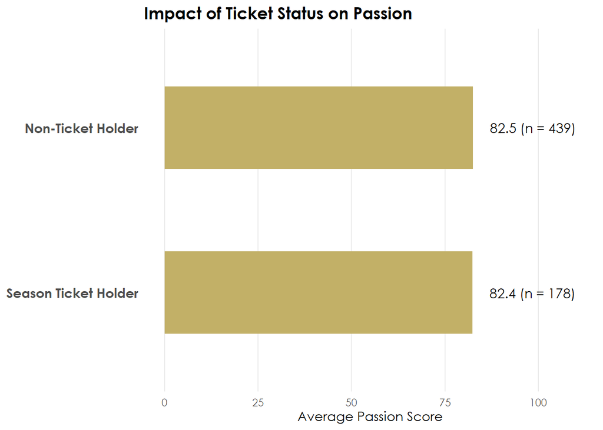

Figure 3: Average Fan Passion by Season Ticket Holder Status

### Predictor: In-Venue Attendance

While baseline passion remains high across the overall fanbase, I also evaluated the impact of physical, in-venue engagement. By analyzing the total number of home games a fan attended during the season, we can determine if repeated physical exposure to the team and its sponsors correlates with heightened team affinity.

While there is a small bump in passion scores as more gamea are attended, it seems like 6 games is the golden number to determine a fans passion.

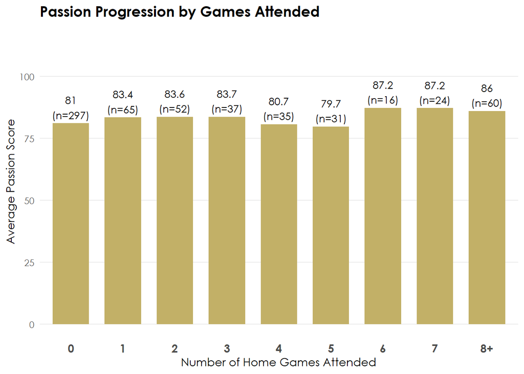

Figure 4: Average Fan Passion by Exact Number of Games Attended

### Predictor: Neighborhood Family Density

To further define the demographic profile of the fanbase, I analyzed life-stage indicators using U.S. Census Bureau ACS data. By calculating the percentage of households with children under 18 in each respondent’s neighborhood, I tested if family-dense environments act as an incubator for team passion.

There is a very slight increase in passion for more family-dense neighborhoods, though nearly negligible.

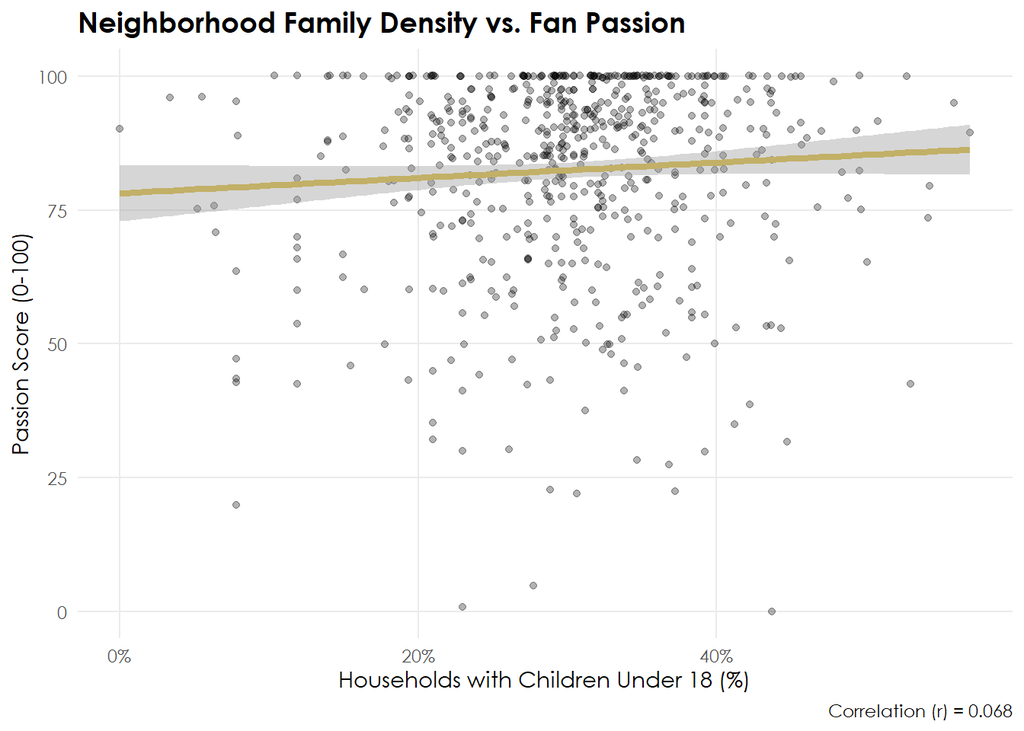

Figure 5: Relationship between Neighborhood Family Density and Fan Passion

### Predictor: Neighborhood Education Level

To evaluate the impact of educational attainment, I analyzed the relationship between fan passion and the percentage of adults (age 25+) holding a Bachelor’s degree or higher in the respondent’s ZIP code.

Fan’s who reside in better educated neighborhoods have slightly less passion.

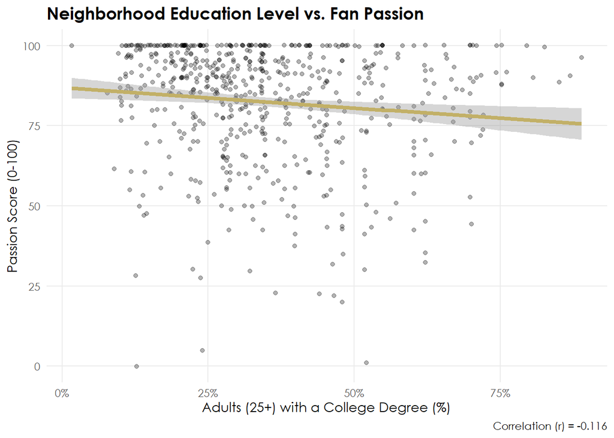

Figure 6: Relationship between Neighborhood Education and Fan Passion

#### Predictor: Neighborhood Education Tiers (ANOVA)

While a continuous correlation provides directional insight, I applied an Analysis of Variance (ANOVA) to test for statistical significance. I segmented the respondent ZIP codes into three equal tiers based on the density of college-educated adults to determine if neighborhood education level creates a proven variance in fan passion.

The analysis shows that fans from lower degree density neighborhood have statistically significantly higher passion score. For brands, this means that targeting efforts in lower degree-dense neighborhoods could be more impactful.

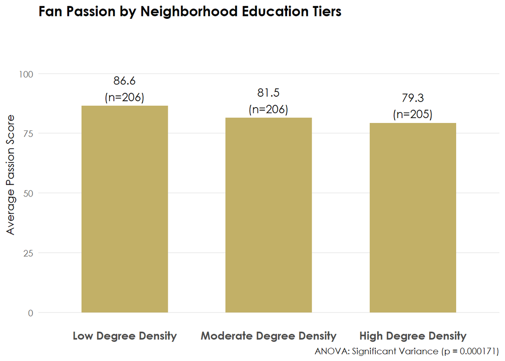

Figure 7: Average Fan Passion by Neighborhood Education Tiers

## Variable Importance Modeling

Taking these predictors, I put them in a Linear Regression Model to see their importance to the Passion score and attempt to see the connection between their external environment (neighborhood, attendance, income), and their internal passion for a team.

By extracting the absolute t-statistics from the model, we can rank the relative importance of each variable in predicting a fan’s Passion Score.

Table 1: Multivariate Linear Regression Output

**Predictors of Fan Passion**

Multivariate Linear Regression Results

| Predictor Variable | Estimate (Coefficient) | Standard Error | t-Statistic | P-Value |
| --- | --- | --- | --- | --- |
| Baseline Passion (Intercept) | 84.669 | 3.827 | 22.123 | 0.000 |
| Neighborhood Income | 0.000 | 0.000 | 2.659 | 0.008 |
| Education Level (% College) | −27.837 | 8.092 | −3.440 | 0.001 |
| Family Density (% Kids) | −9.069 | 11.305 | −0.802 | 0.423 |
| Season Ticket Holder | −3.296 | 2.147 | −1.535 | 0.125 |
| Games Attended | 1.008 | 0.332 | 3.035 | 0.003 |

Model Variance (R-squared): 3.8%

### Relative Variable Importance

I extracted the absolute t-statistics from the model to rank the relative importance of each variable. This allows us to see which demographic or behavioral factor is the strongest independent driver of fan passion.

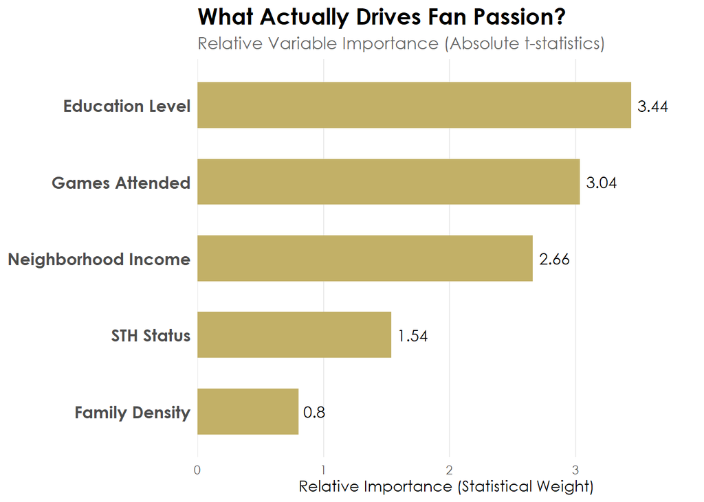

Figure 8: Relative Importance of Predictors on Fan Passion

### Model Validation: Multicollinearity Check (VIF)

I calculated the Variance Inflation Factor for all predictors. High multicollinearity (VIF > 5) can distort coefficient estimates and render a model highly unstable. As shown below, all variables fall safely below the critical threshold, confirming that our predictors are statistically independent.

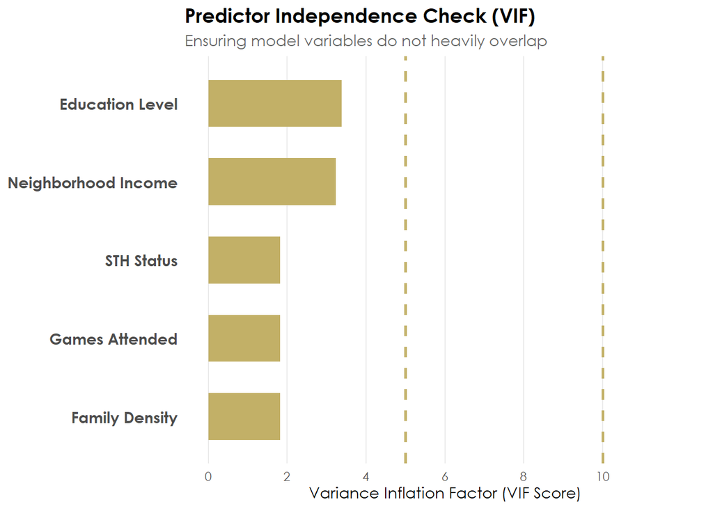

Figure 9: Variance Inflation Factor (VIF) Analysis

## Are Fans Financial Outliers?

**1:** Under $25k

**2:** $25k - $49k

**3:** $50k - $74k

**4:** $75k - $99k

**5:** $100k - $124k

**6:** $125k - $149k

**7:** $150k or more

By categorizing the continuous Census neighborhood median income into these exact same 1-7 brackets, I can directly compare a fan’s individual wealth against their neighbors to determine if Saints fans are financial outliers in their own communities.

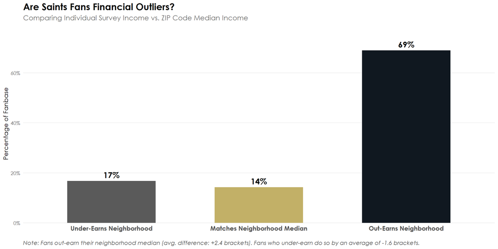

Figure 10: Fan Income vs. Neighborhood Median Income

# Conclusion: The Saints Fan Persona

Through the analysis of individual survey responses and granular U.S. Census data, this analysis reveals the demographic and behavioral profile of the New Orleans Saints fans.

## Further Research

An area of research that could be done to aid the findings in this report (specifically the Ecological Fallacy) is to see if the same holds true in other cities. New Orleans has one of the highest poverty rates among major U.S cities, so the findings may be due to that rather than a pattern of fans residing in lower-income neighborhoods. If this finding holds true for other cities around the country, then there may be more to explore with this topic.